```python
import numpy as np
import pandas as pd
import matplotlib.pyplot as plt
import seaborn as sns
```

## 1. Data preparation and cleanup

```python
df = pd.read_csv('data.csv')
```

```python
df.head()
```

|  | Row ID | Year | Department Title | Payroll Department | Record Number | Job Class Title | Employment Type | Hourly or Event Rate | Projected Annual Salary | Q1 Payments | ... | MOU Title | FMS Department | Job Class | Pay Grade | Average Health Cost | Average Dental Cost | Average Basic Life | Average Benefit Cost | Benefits Plan | Job Class Link |
| --- | --- | --- | --- | --- | --- | --- | --- | --- | --- | --- | --- | --- | --- | --- | --- | --- | --- | --- | --- | --- | --- |
| 0 | 111391 | 2014 | Water And Power (DWP) | NaN | 1412316577 | Commercial Service Representative | Full Time | NaN | $70386.48 | $16129.89 | ... | NaN | 98 | 1230 | NaN | $16842.08 | $1282.61 | $0.00 | $18124.69 | DWP | http://per.lacity.org/perspecs/1230.pdf |
| 1 | 31732 | 2013 | Police (LAPD) | 4301.0 | 432728338 | Police Officer I | Full Time | $25.12 | $52450.56 | $11331.00 | ... | POLICE OFFICERS UNIT | 70 | 2214 | A | $11651.40 | $898.08 | $191.04 | $12740.52 | Police | http://per.lacity.org/perspecs/2214.pdf |
| 2 | 27697 | 2013 | Police (LAPD) | 4301.0 | 97182506 | Police Officer II | Full Time | $42.77 | $89303.76 | $20036.32 | ... | POLICE OFFICERS UNIT | 70 | 2214 | 2 | $11651.40 | $898.08 | $191.04 | $12740.52 | Police | http://per.lacity.org/perspecs/2214.pdf |
| 3 | 14136 | 2013 | Harbor (Port of LA) | 3201.0 | 950136941 | Senior Security Officer | Full Time | $28.75 | $60028.96 | $15793.88 | ... | SUPV BLUE COLLAR | 42 | 3184 | 0 | $10710.24 | $405.24 | $11.40 | $11126.88 | City | http://per.lacity.org/perspecs/3184.pdf |
| 4 | 91896 | 2014 | Public Works - Sanitation | 7024.0 | 3230003445 | Senior Clerk Typist | Full Time | $30.92 | $64553.13 | $14700.00 | ... | CLERICAL UNIT | 82 | 1368 | 0 | $11000.40 | $409.68 | $11.40 | $11421.48 | City | http://per.lacity.org/perspecs/1368.pdf |

5 rows × 35 columns

### Here we observe bad data types and missing values.

```python
df.info()
```

```
<class 'pandas.core.frame.DataFrame'>
RangeIndex: 285008 entries, 0 to 285007
Data columns (total 35 columns):
 #   Column                        Non-Null Count   Dtype
---  ------                        --------------   -----
 0   Row ID                        285008 non-null  int64
 1   Year                          285008 non-null  int64
 2   Department Title              285008 non-null  object
 3   Payroll Department            231463 non-null  float64
 4   Record Number                 285008 non-null  object
 5   Job Class Title               285008 non-null  object
 6   Employment Type               285008 non-null  object
 7   Hourly or Event Rate          263987 non-null  object
 8   Projected Annual Salary       285008 non-null  object
 9   Q1 Payments                   285008 non-null  object
```

[output cut: 27 more lines]

### Delete unnecessary columns, exclude not full time employments.

```python
df.drop(['Row ID', 'Payroll Department', 'Record Number', 'MOU', 'MOU Title', 'FMS Department', 'Job Class', 'Pay Grade', 'Benefits Plan'], axis=1, inplace=True)
df = df[(df['Hourly or Event Rate'].notna()) & (df['Projected Annual Salary'].notna())]
df = df[df['Employment Type'] == 'Full Time'].reset_index(drop=True)
df['Year'] = df['Year'].astype(np.int32)
```

### Transform numeric columns data from string to float, replace NaN with 0.

```python
numeric_cols = [
    'Hourly or Event Rate', 'Projected Annual Salary', 'Q1 Payments',
    'Q2 Payments', 'Q3 Payments', 'Q4 Payments', 'Payments Over Base Pay',
    '% Over Base Pay', 'Total Payments', 'Base Pay', 'Permanent Bonus Pay',
    'Longevity Bonus Pay', 'Temporary Bonus Pay', 'Lump Sum Pay',
    'Overtime Pay', 'Other Pay & Adjustments',
    'Other Pay (Payroll Explorer)', 'Average Health Cost',
    'Average Dental Cost', 'Average Basic Life', 'Average Benefit Cost'
]

for col in numeric_cols:
    df[col] = df[col].apply(lambda x: 0 if type(x) != str else round(float(x.replace('$', '').replace('%', '')), 2)).astype(np.float32)
```

### Now everything is OK.

```python
df.info()
```

```
<class 'pandas.core.frame.DataFrame'>
RangeIndex: 215808 entries, 0 to 215807
Data columns (total 26 columns):
 #   Column                        Non-Null Count   Dtype
---  ------                        --------------   -----
 0   Year                          215808 non-null  int32
 1   Department Title              215808 non-null  object
 2   Job Class Title               215808 non-null  object
 3   Employment Type               215808 non-null  object
 4   Hourly or Event Rate          215808 non-null  float32
 5   Projected Annual Salary       215808 non-null  float32
 6   Q1 Payments                   215808 non-null  float32
 7   Q2 Payments                   215808 non-null  float32
 8   Q3 Payments                   215808 non-null  float32
 9   Q4 Payments                   215808 non-null  float32
```

[output cut: 18 more lines]

## 2. Some descriptive statistics and observations

```python
print(f"Just {len(df['Department Title'].unique())} unique departments")
```

```
Just 58 unique departments
```

```python
df['Department Title'].value_counts()
```

```
Department Title
Police (LAPD)                                                   65429
Water And Power (DWP)                                           32178
Fire (LAFD)                                                     18107
Airports (LAWA)                                                 16944
Public Works - Sanitation                                       12710
General Services                                                 7029
Recreation And Parks                                             7009
Transportation (LADOT)                                           6734
Harbor (Port of LA)                                              4741
Public Works - Street Services                                   4497
City Attorney                                                    4493
Building and Safety                                              4158
Public Works - Engineering                                       3819
Library                                                          3716
Housing And Community Investment Department                      3049
Personnel                                                        2481
Information Technology Agency                                    2336
Office of Finance                                                1659
Animal Services                                                  1604
Public Works - Contract Administration                           1451
City Planning                                                    1113
Public Works - Street Lighting                                   1086
Zoo                                                              1046
Mayor                                                             947
Economic And Workforce Development Department (EWDD)              768
Controller                                                        740
City Employees Retirement System (LACERS)                         669
Pension (LAFPP)                                                   572
City Administrative Officer (CAO)                                 565
City Clerk                                                        476
Public Works - Board of Public Works                              456
City Planning And Development (DCP)                               284
Office of the Chief Legislative Analyst (CLA)                     232
Cultural Affairs                                                  203
Aging                                                             187
Council District 14 (CD 14)                                       138
Neighborhood Empowerment (DONE)                                   126
Emergency Management                                              124
Council District 04 (CD 4)                                        123
Council District 08 (CD 8)                                        118
Council District 11 (CD 11)                                       118
Council District 01 (CD 1)                                        117
Council District 10 (CD 10)                                       117
Council District 05 (CD 5)                                        117
City Ethics Commission                                            116
Council District 15 (CD 15)                                       107
Council District 03 (CD 3)                                        107
Council District 07 (CD 7)                                        107
Council District 13 (CD 13)                                       107
Council District 02 (CD 2)                                        105
Council District 09 (CD 9)                                        104
Council District 06 (CD 6)                                        103
Council District 12 (CD 12)                                        99
Disability                                                         84
Los Angeles Convention Center                                      75
El Pueblo De Los Angeles Historical Monument Authority             47
Los Angeles Department of Convention and Tourism Development       45
Employee Relations Board                                           16
Name: count, dtype: int64
```

```python
print(f"{len(df['Job Class Title'].unique())} unique job positions, it is quite predictable that the LAPD is the largest state employer")
```

```
1549 unique job positions, it is quite predictable that the LAPD is the largest state employer
```

```python
df['Job Class Title'].value_counts()
```

```
Job Class Title
Police Officer II                              21240
Police Officer III                             10953
Firefighter III                                 8766
Police Sergeant I                               3888
Administrative Clerk                            3595
                                               ...
Assistant General Manager Aging                    1
Airport Guide I                                    1
Convention Center Building Superintendent I        1
X-Ray and Laboratory Technician                    1
Refuse Collection Truck Operator I                 1
Name: count, Length: 1549, dtype: int64
```

### Here is the statistics for 4 important columns.

```python
df[['Hourly or Event Rate', 'Projected Annual Salary', 'Total Payments', 'Overtime Pay']].describe()
```

|  | Hourly or Event Rate | Projected Annual Salary | Total Payments | Overtime Pay |
| --- | --- | --- | --- | --- |
| count | 215808.000000 | 215808.000000 | 215808.000000 | 215808.000000 |
| mean | 42.440872 | 88617.273438 | 71245.023438 | 7153.709473 |
| std | 13.734159 | 28676.970703 | 44707.078125 | 15596.591797 |
| min | 0.000000 | 0.000000 | -30728.269531 | -1019.489990 |
| 25% | 32.490002 | 67839.117188 | 35027.184570 | 0.000000 |
| 50% | 41.730000 | 87132.242188 | 63393.949219 | 1019.035004 |
| 75% | 49.779999 | 103940.640625 | 99322.144531 | 6959.900024 |
| max | 172.770004 | 360743.750000 | 500930.750000 | 311315.625000 |

### It seems that the Police Officer III who got more than 500k of annual income and Fire Captain I who got more than 300k of Overtime Pay got it for some extraordinary activities, while General Manager Airports really can earn 172.77$ per hour.

```python
df[(df['Hourly or Event Rate'] == 172.77) | (df['Projected Annual Salary'] == 360743.75) | (df['Total Payments'] == 500930.75) | (df['Overtime Pay'] == 311315.625)]
```

|  | Year | Department Title | Job Class Title | Employment Type | Hourly or Event Rate | Projected Annual Salary | Q1 Payments | Q2 Payments | Q3 Payments | Q4 Payments | ... | Temporary Bonus Pay | Lump Sum Pay | Overtime Pay | Other Pay & Adjustments | Other Pay (Payroll Explorer) | Average Health Cost | Average Dental Cost | Average Basic Life | Average Benefit Cost | Job Class Link |
| --- | --- | --- | --- | --- | --- | --- | --- | --- | --- | --- | --- | --- | --- | --- | --- | --- | --- | --- | --- | --- | --- |
| 15416 | 2013 | Airports (LAWA) | General Manager Airports | Full Time | 172.770004 | 360743.750000 | 79908.242188 | 93961.437500 | 82725.601562 | 96751.203125 | ... | 0.000000 | 0.000000 | 0.000 | 0.000000 | 0.000000 | 10710.240234 | 405.239990 | 11.400000 | 11126.879883 | http://per.lacity.org/perspecs/0161.pdf |
| 31015 | 2014 | Airports (LAWA) | General Manager Airports | Full Time | 172.770004 | 360743.750000 | 82929.601562 | 96751.203125 | 82929.601562 | 96751.203125 | ... | 0.000000 | 0.000000 | 0.000 | 0.000000 | 0.000000 | 11000.400391 | 409.679993 | 11.400000 | 11421.480469 | http://per.lacity.org/perspecs/0161.pdf |
| 40467 | 2013 | Police (LAPD) | Police Officer III | Full Time | 50.119999 | 104642.210938 | 0.000000 | 0.000000 | 0.000000 | 500930.750000 | ... | 1911.040039 | 0.000000 | 0.000 | 428128.968750 | 435621.781250 | 11651.400391 | 898.080017 | 191.039993 | 12740.519531 | http://per.lacity.org/perspecs/2214.pdf |
| 128970 | 2015 | Airports (LAWA) | General Manager Airports | Full Time | 172.770004 | 360743.750000 | 82929.601562 | 96751.203125 | 133839.171875 | 0.000000 | ... | 0.000000 | 116907.710938 | 0.000 | 0.000000 | 116907.710938 | 11012.400391 | 411.359985 | 11.400000 | 11435.160156 | http://per.lacity.org/perspecs/0161.pdf |
| 136787 | 2015 | Fire (LAFD) | Fire Captain I | Full Time | 63.509998 | 132603.656250 | 95633.257812 | 107862.250000 | 122415.218750 | 122683.601562 | ... | 1088.000000 | 2137.629883 | 311315.625 | 3256.679932 | 16449.910156 | 13031.400391 | 896.760010 | 178.679993 | 14106.839844 | http://per.lacity.org/perspecs/2142.pdf |

5 rows × 26 columns

## 3. Some basic plots

### It seems that there are no interesting correletions that requires an additional research. The only thing is that the correletion 1 between Average Benefit Cost and Average Health Cost points to the linear dependence between that parameters, but in the case of the project there is no need to investigate the nature of the dependence.

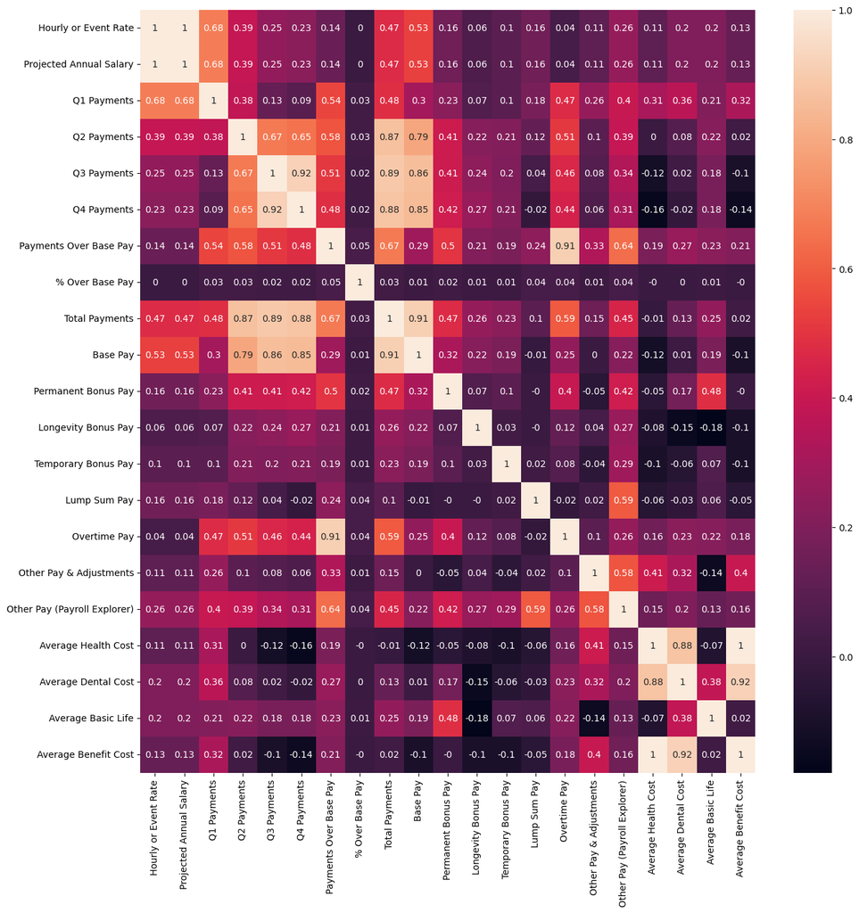

```python
corr = df[numeric_cols].corr().round(2)

fig, ax = plt.subplots(figsize=(15, 15))
sns.heatmap(corr, ax=ax, annot=True);
```

### There was a stable increase of mean and median salary from year to year.

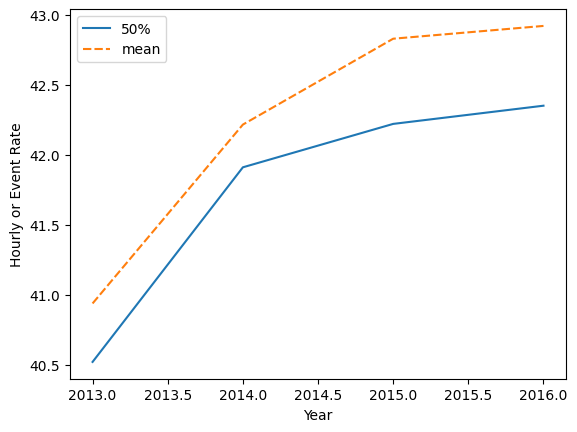

```python
sns.lineplot(df.groupby('Year')['Hourly or Event Rate'].describe()[['50%', 'mean']]).set(ylabel='Hourly or Event Rate');
```

### Top-3 state employers' hour rates. It is clearly seen that LAPD has significantly bigger median rate than LAFD and DWP. And that very few people earn more than 75$ per hour.

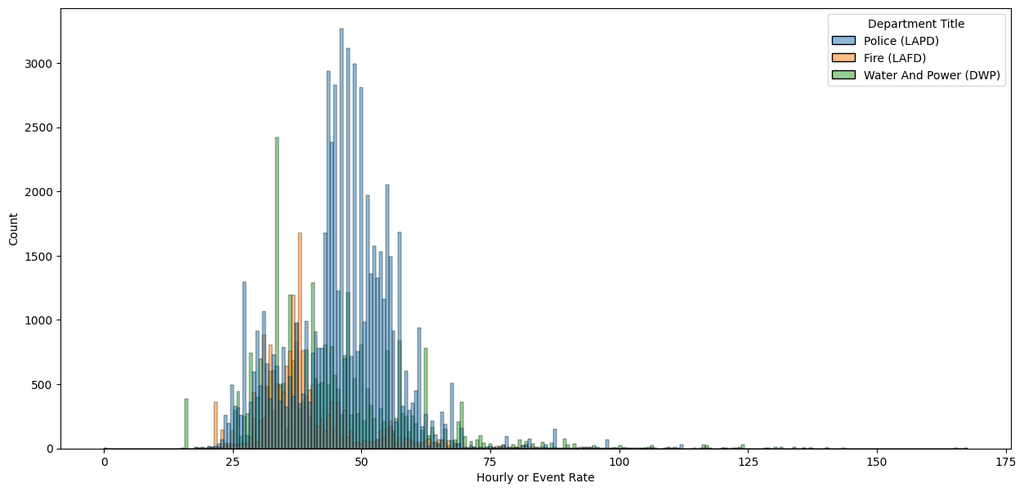

```python
fig, ax = plt.subplots(figsize=(15, 7))

sns.histplot(df[df['Department Title'].isin(['Police (LAPD)', 'Water And Power (DWP)', 'Fire (LAFD)'])], x='Hourly or Event Rate', hue='Department Title', ax=ax);
```

## 4. Detailed data overview

### Top-3 state employers are also top-3 employers whose workers often do some extra work which is generously rewarded by the departments. But there are harbor, building and safety, transportation and airports workers who are usually overworked too.

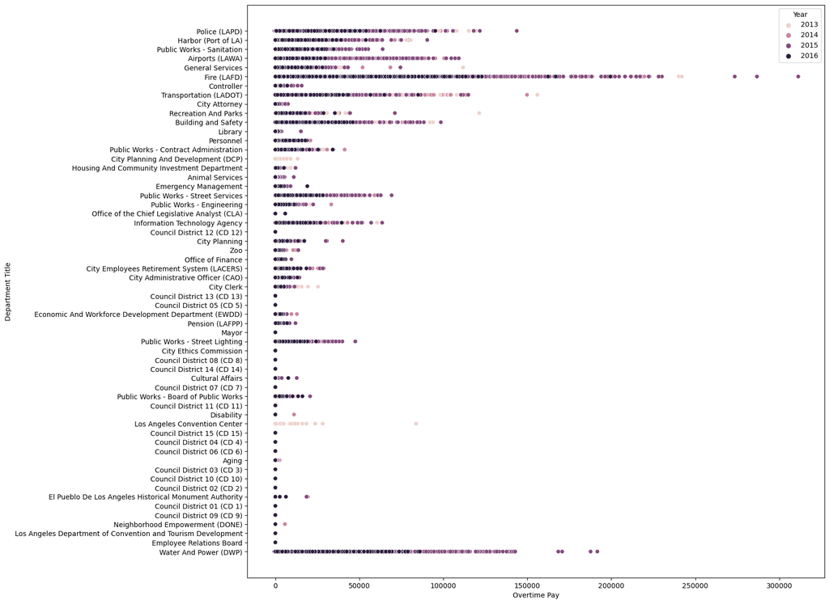

```python
fig, ax = plt.subplots(figsize=(15, 15))

sns.scatterplot(data=df, x='Overtime Pay', y='Department Title', hue='Year', ax=ax);
```

### The boxplot graph shows that LAFD is the top leader by the amount of over base payments.

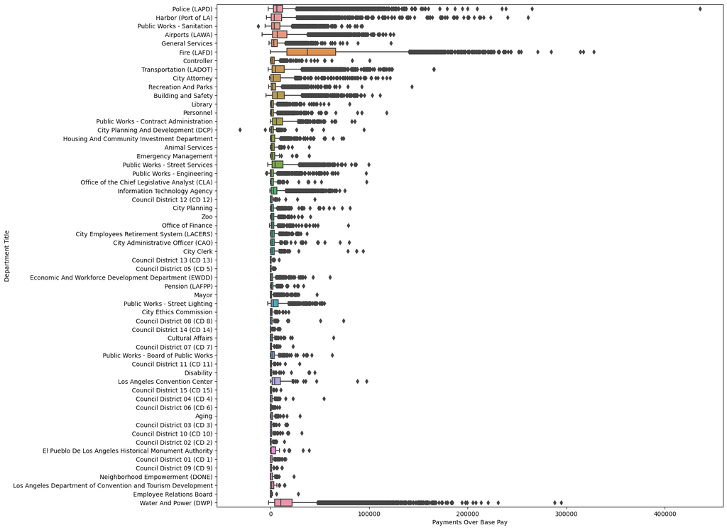

```python
fig, ax = plt.subplots(figsize=(15, 15))

sns.boxplot(data=df, x='Payments Over Base Pay', y='Department Title', ax=ax);
```

## 5. Hypothesis check

### Hypothesis: mayor position should be one of the most highly-payed positions through the LA state positions.

### The first look at the mayor's salary information.

```python
df[(df['Job Class Title'] == 'Mayor')][['Year', 'Hourly or Event Rate', 'Projected Annual Salary', 'Total Payments', 'Overtime Pay']]
```

|  | Year | Hourly or Event Rate | Projected Annual Salary | Total Payments | Overtime Pay |
| --- | --- | --- | --- | --- | --- |
| 5831 | 2014 | 114.940002 | 239992.890625 | 231464.500000 | 0.0 |
| 35780 | 2016 | 117.699997 | 245753.421875 | 65910.882812 | 0.0 |
| 68638 | 2013 | 111.320000 | 232425.718750 | 194164.281250 | 0.0 |
| 79174 | 2013 | 111.320000 | 232425.718750 | 125958.890625 | 0.0 |
| 101133 | 2015 | 117.699997 | 245753.421875 | 237452.953125 | 0.0 |
| 182756 | 2016 | 117.699997 | 245753.421875 | 122405.921875 | 0.0 |

### More surprisingly, mayor is just on the 31st place in the list of the most well-payed state jobs in LA. The more well-payed jobs are connected with the management of some city departments.

```python
df.sort_values('Hourly or Event Rate', ascending=False).drop_duplicates(['Job Class Title']).head(40)
```

|  | Year | Department Title | Job Class Title | Employment Type | Hourly or Event Rate | Projected Annual Salary | Q1 Payments | Q2 Payments | Q3 Payments | Q4 Payments | ... | Temporary Bonus Pay | Lump Sum Pay | Overtime Pay | Other Pay & Adjustments | Other Pay (Payroll Explorer) | Average Health Cost | Average Dental Cost | Average Basic Life | Average Benefit Cost | Job Class Link |
| --- | --- | --- | --- | --- | --- | --- | --- | --- | --- | --- | --- | --- | --- | --- | --- | --- | --- | --- | --- | --- | --- |
| 15416 | 2013 | Airports (LAWA) | General Manager Airports | Full Time | 172.770004 | 360743.750000 | 79908.242188 | 93961.437500 | 82725.601562 | 96751.203125 | ... | 0.000000 | 0.000000 | 0.000000 | 0.000000 | 0.000000 | 10710.240234 | 405.239990 | 11.400000 | 11126.879883 | http://per.lacity.org/perspecs/0161.pdf |
| 210502 | 2016 | Water And Power (DWP) | General Manager & Chief Engineer Water & Power | Full Time | 167.630005 | 350011.437500 | 107268.203125 | 80462.398438 | 0.000000 | 0.000000 | ... | 0.000000 | 0.000000 | 0.000000 | 13395.400391 | 13395.400391 | 18144.429688 | 1248.189941 | 0.000000 | 19392.619141 | http://per.lacity.org/perspecs/9998.pdf |
| 37483 | 2016 | Police (LAPD) | Chief of Police | Full Time | 165.580002 | 345731.031250 | 100672.640625 | 0.000000 | 0.000000 | 0.000000 | ... | 0.000000 | 7947.839844 | 0.000000 | 0.000000 | 7947.839844 | 11973.120117 | 873.239990 | 192.360001 | 13038.719727 | http://per.lacity.org/perspecs/9359.pdf |
| 180439 | 2016 | Harbor (Port of LA) | General Manager Harbor Department | Full Time | 153.250000 | 319986.000000 | 87320.000000 | 77450.703125 | 0.000000 | 0.000000 | ... | 2390.699951 | 0.000000 | 0.000000 | 3000.000000 | 5390.700195 | 11470.339844 | 412.339996 | 11.450000 | 11894.129883 | http://per.lacity.org/perspecs/9289.pdf |
| 30771 | 2016 | Harbor (Port of LA) | Chief Port Pilot II | Full Time | 145.050003 | 302864.406250 | 138737.265625 | 0.000000 | 0.000000 | 0.000000 | ... | 48943.859375 | 6962.399902 | 0.000000 | 1603.000000 | 57509.261719 | 11012.400391 | 411.359985 | 11.400000 | 11435.160156 | http://per.lacity.org/perspecs/5154.pdf |
| 142012 | 2016 | Fire (LAFD) | Fire Chief | Full Time | 143.550003 | 299732.406250 | 80108.000000 | 71139.179688 | 0.000000 | 0.000000 | ... | 2235.179932 | 0.000000 | 0.000000 | 0.000000 | 2235.179932 | 12630.040039 | 929.219971 | 192.740005 | 13752.000000 | http://per.lacity.org/perspecs/9339.pdf |
| 137859 | 2016 | City Administrative Officer (CAO) | City Administrative Officer | Full Time | 143.330002 | 299273.031250 | 79659.203125 | 71030.203125 | 0.000000 | 0.000000 | ... | 2231.800049 | 0.000000 | 0.000000 | 0.000000 | 2231.800049 | 11470.339844 | 412.339996 | 11.450000 | 11894.129883 | http://per.lacity.org/perspecs/0010.pdf |
| 140448 | 2016 | Office of the Chief Legislative Analyst (CLA) | Chief Legislative Analyst | Full Time | 143.330002 | 299273.031250 | 87675.679688 | 72516.218750 | 0.000000 | 0.000000 | ... | 2217.820068 | 6516.479980 | 0.000000 | 3000.000000 | 11734.299805 | 11470.339844 | 412.339996 | 11.450000 | 11894.129883 | http://per.lacity.org/perspecs/9296.pdf |
| 24910 | 2016 | Airports (LAWA) | Assistant General Manager Airports | Full Time | 143.169998 | 298938.968750 | 80271.203125 | 71051.000000 | 0.000000 | 0.000000 | ... | 2233.399902 | 0.000000 | 0.000000 | 192.000000 | 2425.399902 | 11470.339844 | 412.339996 | 11.450000 | 11894.129883 | http://per.lacity.org/perspecs/0160.pdf |
| 205210 | 2016 | Water And Power (DWP) | Assistant General Manager Water and Power | Full Time | 140.100006 | 292528.812500 | 85834.398438 | 65333.199219 | 0.000000 | 0.000000 | ... | 0.000000 | 0.000000 | 0.000000 | 10866.799805 | 10866.799805 | 18144.429688 | 1248.189941 | 0.000000 | 19392.619141 | http://per.lacity.org/perspecs/151.pdf |
| 208453 | 2016 | Water And Power (DWP) | Electrical Service Manager | Full Time | 137.250000 | 286578.000000 | 88017.000000 | 66169.507812 | 0.000000 | 0.000000 | ... | 0.000000 | 0.000000 | 0.000000 | 11446.509766 | 18986.509766 | 18144.429688 | 1248.189941 | 0.000000 | 19392.619141 | http://per.lacity.org/perspecs/5265.pdf |
| 115526 | 2015 | Fire (LAFD) | Fire Deputy Chief | Full Time | 136.050003 | 284072.406250 | 77090.882812 | 85671.203125 | 88532.796875 | 66706.296875 | ... | 1320.000000 | 19463.039062 | 17072.640625 | 1006.299988 | 68336.539062 | 13031.400391 | 896.760010 | 178.679993 | 14106.839844 | http://per.lacity.org/perspecs/2176.pdf |
| 86599 | 2016 | Water And Power (DWP) | Power Engineering Manager | Full Time | 135.839996 | 283633.906250 | 87108.601562 | 0.000000 | 0.000000 | 0.000000 | ... | 0.000000 | 0.000000 | 0.000000 | 11038.200195 | 17780.599609 | 17486.939453 | 1268.689941 | 0.000000 | 18755.630859 | http://per.lacity.org/perspecs/9453.pdf |
| 80496 | 2013 | Fire (LAFD) | FIRE CHIEF | Full Time | 134.929993 | 281733.843750 | 42844.000000 | 50201.601562 | 43608.800781 | 68862.796875 | ... | 0.000000 | 0.000000 | 0.000000 | 1200.000000 | 1200.000000 | 10710.240234 | 405.239990 | 11.400000 | 11126.879883 | http://per.lacity.org/perspecs/9339.pdf |
| 126287 | 2015 | Water And Power (DWP) | Auditor Water And Power | Full Time | 133.960007 | 279708.468750 | 79332.000000 | 63034.398438 | 77367.382812 | 65610.562500 | ... | 0.000000 | 0.000000 | 0.000000 | 14366.179688 | 18533.779297 | 17486.939453 | 1268.689941 | 0.000000 | 18755.630859 | http://per.lacity.org/perspecs/9759.pdf |
| 197372 | 2016 | Public Works - Engineering | City Engineer | Full Time | 133.830002 | 279437.031250 | 82607.843750 | 67822.281250 | 0.000000 | 0.000000 | ... | 2083.879883 | 6423.839844 | 0.000000 | 3000.000000 | 11507.719727 | 11470.339844 | 412.339996 | 11.450000 | 11894.129883 | http://per.lacity.org/perspecs/9497.pdf |
| 137863 | 2016 | City Administrative Officer (CAO) | Executive Director Office of Public Accountabi... | Full Time | 131.809998 | 275219.281250 | 75313.601562 | 66825.007812 | 0.000000 | 0.000000 | ... | 2056.209961 | 0.000000 | 0.000000 | 3000.000000 | 5056.209961 | 11470.339844 | 412.339996 | 11.450000 | 11894.129883 | http://per.lacity.org/perspecs/0748.pdf |
| 132316 | 2015 | Police (LAPD) | Police Deputy Chief II | Full Time | 131.550003 | 274676.406250 | 70047.843750 | 73656.796875 | 75156.796875 | 67039.203125 | ... | 6000.000000 | 6313.439941 | 0.000000 | 0.000000 | 12932.639648 | 11973.120117 | 873.239990 | 192.360001 | 13038.719727 | http://per.lacity.org/perspecs/2262.pdf |
| 45644 | 2016 | Airports (LAWA) | Deputy General Manager Airports/1 | Full Time | 130.089996 | 271627.906250 | 72850.398438 | 62443.199219 | 0.000000 | 0.000000 | ... | 0.000000 | 0.000000 | 0.000000 | 0.000000 | 0.000000 | 11470.339844 | 412.339996 | 11.450000 | 11894.129883 | http://per.lacity.org/perspecs/0162.pdf |
| 119633 | 2015 | Water And Power (DWP) | General Services Manager | Full Time | 129.979996 | 271398.250000 | 89205.921875 | 62459.398438 | 75658.781250 | 68340.296875 | ... | 0.000000 | 0.000000 | 0.000000 | 50471.761719 | 52735.441406 | 17486.939453 | 1268.689941 | 0.000000 | 18755.630859 | http://per.lacity.org/perspecs/9601.pdf |
| 69479 | 2014 | Harbor (Port of LA) | First Deputy General Manager Harbor | Full Time | 129.800003 | 271027.875000 | 63046.128906 | 74292.468750 | 63679.261719 | 74292.468750 | ... | 0.000000 | 0.000000 | 0.000000 | 5954.000000 | 25995.009766 | 11000.400391 | 409.679993 | 11.400000 | 11421.480469 | http://per.lacity.org/perspecs/0805.pdf |
| 105677 | 2015 | Water And Power (DWP) | Water Service Supervisor | Full Time | 128.669998 | 268662.968750 | 82537.796875 | 51579.000000 | 185200.984375 | 1834.050049 | ... | 0.000000 | 0.000000 | 0.000000 | 197628.625000 | 197628.625000 | 17486.939453 | 1268.689941 | 0.000000 | 18755.630859 | http://per.lacity.org/perspecs/9602.pdf |
| 139081 | 2016 | City Employees Retirement System (LACERS) | General Manager LACERS | Full Time | 127.519997 | 266261.750000 | 77587.203125 | 64691.578125 | 0.000000 | 0.000000 | ... | 1981.979980 | 5355.839844 | 0.000000 | 3000.000000 | 10337.820312 | 11470.339844 | 412.339996 | 11.450000 | 11894.129883 | http://per.lacity.org/perspecs/9150.pdf |
| 211396 | 2016 | Water And Power (DWP) | Managing Water Utility Engineer | Full Time | 123.800003 | 258494.406250 | 79880.859375 | 59962.359375 | 0.000000 | 0.000000 | ... | 0.000000 | 0.000000 | 0.000000 | 11091.219727 | 11091.219727 | 18144.429688 | 1248.189941 | 0.000000 | 19392.619141 | http://per.lacity.org/perspecs/9406.pdf |
| 177252 | 2016 | Water And Power (DWP) | Principal Utility Accountant | Full Time | 123.269997 | 257387.765625 | 78992.796875 | 0.000000 | 0.000000 | 0.000000 | ... | 0.000000 | 0.000000 | 0.000000 | 9961.599609 | 13607.200195 | 17486.939453 | 1268.689941 | 0.000000 | 18755.630859 | http://per.lacity.org/perspecs/1589.pdf |
| 50549 | 2013 | Airports (LAWA) | Deputy General Manager Airports I | Full Time | 123.209999 | 257257.265625 | 58123.621094 | 67810.890625 | 58970.269531 | 68996.203125 | ... | 0.000000 | 0.000000 | 0.000000 | 0.000000 | 6795.379883 | 10710.240234 | 405.239990 | 11.400000 | 11126.879883 | http://per.lacity.org/perspecs/0162.pdf |
| 126979 | 2015 | Water And Power (DWP) | Medical Director | Full Time | 122.529999 | 255842.640625 | 68716.796875 | 59401.398438 | 71275.226562 | 60366.988281 | ... | 0.000000 | 0.000000 | 0.000000 | 4898.020020 | 4898.020020 | 17486.939453 | 1268.689941 | 0.000000 | 18755.630859 | http://per.lacity.org/perspecs/2334.pdf |
| 165904 | 2016 | Pension (LAFPP) | General Manager Los Angeles Fire & Police Pens... | Full Time | 121.650002 | 254005.203125 | 74976.601562 | 0.000000 | 0.000000 | 0.000000 | ... | 0.000000 | 5352.600098 | 0.000000 | 1500.000000 | 6852.600098 | 11012.400391 | 411.359985 | 11.400000 | 11435.160156 | http://per.lacity.org/perspecs/9267.pdf |
| 35983 | 2013 | Transportation (LADOT) | General Manager Transportation | Full Time | 121.089996 | 252835.921875 | 62985.039062 | 67108.000000 | 58280.000000 | 68110.398438 | ... | 0.000000 | 5726.399902 | 0.000000 | 1200.000000 | 6926.399902 | 10710.240234 | 405.239990 | 11.400000 | 11126.879883 | http://per.lacity.org/perspecs/9256.pdf |
| 163911 | 2016 | Police (LAPD) | Chief Information Officer | Full Time | 120.010002 | 250587.671875 | 67207.460938 | 0.000000 | 0.000000 | 0.000000 | ... | 0.000000 | 0.000000 | 0.000000 | 0.000000 | 3231.540039 | 11012.400391 | 411.359985 | 11.400000 | 11435.160156 | http://per.lacity.org/perspecs/9374.pdf |
| 182756 | 2016 | Mayor | Mayor | Full Time | 117.699997 | 245753.421875 | 65910.882812 | 56495.039062 | 0.000000 | 0.000000 | ... | 0.000000 | 0.000000 | 0.000000 | 0.000000 | 0.000000 | 11470.339844 | 412.339996 | 11.450000 | 11894.129883 | http://per.lacity.org/perspecs/0004.pdf |
| 97514 | 2015 | City Attorney | Executive Assistant City Attorney | Full Time | 117.529999 | 245402.640625 | 55068.601562 | 64463.800781 | 65975.796875 | 56825.398438 | ... | 0.000000 | 0.000000 | 0.000000 | 1644.000000 | 1644.000000 | 11012.400391 | 411.359985 | 11.400000 | 11435.160156 | http://per.lacity.org/perspecs/0556.pdf |
| 179388 | 2016 | Water And Power (DWP) | Utility Services Manager | Full Time | 116.760002 | 243794.875000 | 72852.000000 | 0.000000 | 0.000000 | 0.000000 | ... | 0.000000 | 0.000000 | 0.000000 | 8947.200195 | 8947.200195 | 17486.939453 | 1268.689941 | 0.000000 | 18755.630859 | http://per.lacity.org/perspecs/9106.pdf |
| 197649 | 2016 | Public Works - Engineering | Deputy City Engineer II | Full Time | 116.480003 | 243217.296875 | 70355.960938 | 55912.019531 | 0.000000 | 0.000000 | ... | 0.000000 | 5125.270020 | 0.000000 | 0.000000 | 17130.380859 | 11470.339844 | 412.339996 | 11.450000 | 11894.129883 | http://per.lacity.org/perspecs/9490.pdf |
| 85938 | 2014 | Personnel | General Manager Personnel Department | Full Time | 116.449997 | 243147.593750 | 60340.769531 | 66712.000000 | 118718.476562 | 0.000000 | ... | 0.000000 | 114742.078125 | 0.000000 | 3250.000000 | 117992.078125 | 11000.400391 | 409.679993 | 11.400000 | 11421.480469 | http://per.lacity.org/perspecs/9295.pdf |
| 82021 | 2014 | Pension (LAFPP) | General Manager LAFPP | Full Time | 115.860001 | 241920.906250 | 59759.519531 | 63290.398438 | 54463.199219 | 67620.921875 | ... | 0.000000 | 5296.319824 | 0.000000 | 6000.000000 | 11296.320312 | 11000.400391 | 409.679993 | 11.400000 | 11421.480469 | http://per.lacity.org/perspecs/9267.pdf |
| 48735 | 2014 | Fire (LAFD) | Fire Assistant Chief | Full Time | 115.570000 | 241310.156250 | 55737.601562 | 65027.199219 | 55737.601562 | 65027.199219 | ... | 1144.000000 | 0.000000 | 0.000000 | 0.000000 | 56313.601562 | 12998.639648 | 890.400024 | 165.240005 | 14054.280273 | http://per.lacity.org/perspecs/2166.pdf |
| 171663 | 2016 | Office of Finance | Director of Finance | Full Time | 114.949997 | 240015.593750 | 68182.406250 | 0.000000 | 0.000000 | 0.000000 | ... | 0.000000 | 5296.029785 | 0.000000 | 250.000000 | 9657.209961 | 11012.400391 | 411.359985 | 11.400000 | 11435.160156 | http://per.lacity.org/perspecs/9650.pdf |
| 147491 | 2016 | Building and Safety | Superintendent of Building | Full Time | 114.870003 | 239848.562500 | 70657.476562 | 0.000000 | 0.000000 | 0.000000 | ... | 0.000000 | 5054.279785 | 0.000000 | 1500.000000 | 6554.279785 | 11012.400391 | 411.359985 | 11.400000 | 11435.160156 | http://per.lacity.org/perspecs/9205.pdf |
| 171931 | 2016 | Zoo | General Manager Los Angeles Zoo | Full Time | 114.279999 | 238616.640625 | 69259.039062 | 0.000000 | 0.000000 | 0.000000 | ... | 0.000000 | 5485.439941 | 0.000000 | 0.000000 | 5485.439941 | 11012.400391 | 411.359985 | 11.400000 | 11435.160156 | http://per.lacity.org/perspecs/9500.pdf |

40 rows × 26 columns

### It is a good-to-hear fact that the highest median hourly rate is in the City Attorney, while Mayor's Office is just on the 37th, what is still unbelievable.

```python
df.groupby('Department Title')[['Hourly or Event Rate']].describe().sort_values([('Hourly or Event Rate', '50%')], ascending=False)
```

| Department Title | Hourly or Event Rate count | Hourly or Event Rate mean | Hourly or Event Rate std | Hourly or Event Rate min | Hourly or Event Rate 25% | Hourly or Event Rate 50% | Hourly or Event Rate 75% | Hourly or Event Rate max |
| --- | --- | --- | --- | --- | --- | --- | --- | --- |
| City Attorney | 4493.0 | 58.510056 | 25.079199 | 16.510000 | 34.650002 | 59.110001 | 80.070000 | 117.529999 |
| City Administrative Officer (CAO) | 565.0 | 55.657169 | 21.102333 | 17.620001 | 38.959999 | 55.689999 | 67.099998 | 143.330002 |
| Emergency Management | 124.0 | 52.252010 | 14.080681 | 30.990000 | 43.407500 | 50.590000 | 55.430000 | 97.339996 |
| Information Technology Agency | 2336.0 | 48.620277 | 13.198466 | 19.059999 | 41.419998 | 47.480000 | 56.200001 | 112.660004 |
| Public Works - Engineering | 3819.0 | 47.277306 | 13.135570 | 18.610001 | 37.310001 | 46.700001 | 55.209999 | 133.830002 |
| Police (LAPD) | 65429.0 | 46.411472 | 10.482169 | 0.000000 | 41.330002 | 46.570000 | 52.580002 | 165.580002 |
| Los Angeles Department of Convention and Tourism Development | 45.0 | 53.956669 | 25.814085 | 22.010000 | 35.470001 | 45.259998 | 70.070000 | 112.070000 |
| City Ethics Commission | 116.0 | 49.215084 | 17.621403 | 26.250000 | 35.214999 | 45.259998 | 63.512502 | 94.839996 |
| Controller | 740.0 | 48.136902 | 16.662188 | 18.610001 | 35.520000 | 44.650002 | 56.730000 | 110.320000 |
| Building and Safety | 4158.0 | 43.136997 | 11.620072 | 0.000000 | 36.590000 | 44.160000 | 48.959999 | 114.870003 |
| Harbor (Port of LA) | 4741.0 | 45.121006 | 18.270100 | 13.310000 | 32.180000 | 42.930000 | 53.630001 | 153.250000 |
| City Planning | 1113.0 | 43.965946 | 14.458216 | 17.620001 | 30.990000 | 42.869999 | 52.410000 | 108.739998 |
| Water And Power (DWP) | 32178.0 | 44.562405 | 14.222895 | 10.140000 | 33.970001 | 42.500000 | 51.240002 | 167.630005 |
| Public Works - Contract Administration | 1451.0 | 43.967667 | 9.302358 | 17.620001 | 41.299999 | 42.209999 | 46.470001 | 107.239998 |
| Housing And Community Investment Department | 3049.0 | 40.923847 | 13.149094 | 17.620001 | 30.959999 | 41.730000 | 47.310001 | 109.660004 |
| Economic And Workforce Development Department (EWDD) | 768.0 | 43.148464 | 13.943671 | 22.010000 | 33.369999 | 41.730000 | 48.009998 | 103.389999 |
| El Pueblo De Los Angeles Historical Monument Authority | 47.0 | 45.560207 | 16.429388 | 25.070000 | 32.460001 | 41.730000 | 53.459999 | 76.480003 |
| City Planning And Development (DCP) | 284.0 | 42.711372 | 12.799369 | 19.260000 | 34.389999 | 41.730000 | 49.340000 | 107.129997 |
| Office of the Chief Legislative Analyst (CLA) | 232.0 | 49.531769 | 24.317013 | 22.620001 | 33.564999 | 41.434999 | 58.580002 | 143.330002 |
| Public Works - Street Lighting | 1086.0 | 40.618122 | 11.827222 | 19.639999 | 30.990000 | 41.330002 | 48.139999 | 101.669998 |
| Office of Finance | 1659.0 | 40.954113 | 12.836984 | 14.480000 | 32.730000 | 40.459999 | 46.150002 | 114.949997 |
| Aging | 187.0 | 41.512459 | 13.840180 | 22.010000 | 32.180000 | 40.060001 | 46.355000 | 89.449997 |
| Disability | 84.0 | 42.332500 | 13.576835 | 18.610001 | 35.377501 | 39.060001 | 45.259998 | 84.730003 |
| Neighborhood Empowerment (DONE) | 126.0 | 38.071587 | 13.458707 | 13.660000 | 28.969999 | 39.049999 | 42.369999 | 80.470001 |
| Personnel | 2481.0 | 41.997303 | 15.805708 | 18.610001 | 30.990000 | 38.389999 | 49.299999 | 116.449997 |
| Pension (LAFPP) | 572.0 | 44.283024 | 18.813951 | 16.680000 | 32.700001 | 37.514999 | 53.347501 | 121.650002 |
| Fire (LAFD) | 18107.0 | 39.466927 | 10.824741 | 17.620001 | 33.320000 | 37.230000 | 41.950001 | 143.550003 |
| Council District 10 (CD 10) | 117.0 | 42.290760 | 21.265085 | 12.730000 | 26.549999 | 36.779999 | 51.119999 | 90.540001 |
| City Clerk | 476.0 | 42.448742 | 15.284365 | 16.799999 | 30.990000 | 36.719999 | 50.639999 | 101.519997 |
| Public Works - Street Services | 4497.0 | 36.770351 | 10.018295 | 9.360000 | 29.600000 | 36.209999 | 43.200001 | 96.830002 |
| Cultural Affairs | 203.0 | 39.908028 | 14.337448 | 17.650000 | 30.450001 | 35.919998 | 45.549999 | 99.970001 |
| City Employees Retirement System (LACERS) | 669.0 | 40.981258 | 17.126780 | 17.620001 | 30.990000 | 35.720001 | 45.259998 | 127.519997 |
| Public Works - Board of Public Works | 456.0 | 40.915443 | 13.741408 | 17.620001 | 32.239999 | 35.520000 | 44.650002 | 86.730003 |
| Public Works - Sanitation | 12710.0 | 38.035015 | 10.893319 | 14.040000 | 30.910000 | 35.380001 | 45.259998 | 112.250000 |
| Council District 11 (CD 11) | 118.0 | 39.679745 | 16.720606 | 18.049999 | 28.182500 | 35.215000 | 44.490002 | 90.540001 |
| General Services | 7029.0 | 34.886932 | 12.258687 | 11.940000 | 24.309999 | 35.189999 | 42.220001 | 108.220001 |
| Mayor | 947.0 | 39.746208 | 18.205336 | 0.000000 | 28.820000 | 34.849998 | 44.135000 | 117.699997 |
| Council District 01 (CD 1) | 117.0 | 36.506752 | 16.758156 | 15.340000 | 26.549999 | 34.830002 | 43.299999 | 90.540001 |
| Employee Relations Board | 16.0 | 42.286877 | 15.688269 | 27.049999 | 30.965000 | 34.775002 | 61.469999 | 66.230003 |
| Los Angeles Convention Center | 75.0 | 36.781731 | 15.925082 | 16.340000 | 27.510000 | 34.320000 | 41.875000 | 110.410004 |
| Airports (LAWA) | 16944.0 | 37.513325 | 14.449230 | 9.360000 | 26.290001 | 33.639999 | 45.259998 | 172.770004 |
| Council District 09 (CD 9) | 104.0 | 38.126537 | 18.958237 | 12.390000 | 25.667500 | 33.394999 | 44.525002 | 90.589996 |
| Transportation (LADOT) | 6734.0 | 36.187786 | 10.712469 | 12.570000 | 30.469999 | 32.150002 | 41.419998 | 121.089996 |
| Council District 13 (CD 13) | 107.0 | 35.703644 | 16.768526 | 15.800000 | 24.480000 | 32.119999 | 39.900002 | 90.540001 |
| Recreation And Parks | 7009.0 | 32.942776 | 9.432706 | 14.510000 | 26.500000 | 31.299999 | 36.180000 | 113.830002 |
| Council District 04 (CD 4) | 123.0 | 35.362278 | 18.768503 | 0.000000 | 22.565000 | 31.260000 | 40.455000 | 90.540001 |
| Council District 12 (CD 12) | 99.0 | 36.966667 | 21.420048 | 13.080000 | 19.059999 | 31.209999 | 44.490002 | 90.540001 |
| Library | 3716.0 | 34.159866 | 11.110424 | 15.340000 | 25.090000 | 30.980000 | 41.490002 | 106.720001 |
| Zoo | 1046.0 | 32.386345 | 11.196310 | 14.510000 | 26.719999 | 30.540001 | 33.625001 | 114.279999 |
| Council District 06 (CD 6) | 103.0 | 33.079224 | 20.153570 | 14.580000 | 18.549999 | 29.559999 | 36.790001 | 90.540001 |
| Council District 05 (CD 5) | 117.0 | 32.474361 | 17.413202 | 14.580000 | 18.549999 | 28.770000 | 37.790001 | 90.540001 |
| Council District 07 (CD 7) | 107.0 | 32.697571 | 18.337446 | 15.120000 | 18.049999 | 28.760000 | 38.720001 | 90.540001 |
| Council District 02 (CD 2) | 105.0 | 35.014381 | 18.522638 | 14.980000 | 21.959999 | 27.240000 | 44.490002 | 90.540001 |
| Council District 03 (CD 3) | 107.0 | 32.730747 | 19.295444 | 12.390000 | 19.580000 | 27.240000 | 36.285000 | 90.540001 |
| Animal Services | 1604.0 | 29.771561 | 9.008977 | 18.610001 | 25.570000 | 27.010000 | 31.500000 | 104.529999 |
| Council District 15 (CD 15) | 107.0 | 32.898689 | 18.119068 | 14.580000 | 22.264999 | 26.549999 | 36.244999 | 90.540001 |
| Council District 14 (CD 14) | 138.0 | 33.266087 | 18.226799 | 15.340000 | 19.272500 | 25.840000 | 42.270000 | 90.540001 |
| Council District 08 (CD 8) | 118.0 | 32.668983 | 21.202126 | 14.190000 | 18.049999 | 23.820000 | 40.762500 | 95.320000 |

### Outcome: the hypothesis has not been proved.

## 6. Data transformation

### Absolute leader by per employee spendings is LAFD, top-2 and top-3 are City Attorney and CAO. The outsiders are Council Districts and Animal Services.

```python
df_by_departments = df.groupby('Department Title')
per_person_spendings = df_by_departments[['Total Payments']].sum() / df_by_departments[['Total Payments']].count()
per_person_spendings.columns = ['Per Person Spendings']
per_person_spendings.sort_values(['Per Person Spendings'], ascending=False)
```

| Department Title | Per Person Spendings |
| --- | --- |
| Fire (LAFD) | 113753.049318 |
| City Attorney | 88463.946584 |
| City Administrative Officer (CAO) | 83340.502655 |
| City Planning And Development (DCP) | 80285.345070 |
| Emergency Management | 79565.193548 |
| Los Angeles Department of Convention and Tourism Development | 77321.233333 |
| Information Technology Agency | 77189.082192 |
| Harbor (Port of LA) | 75841.444421 |
| Office of the Chief Legislative Analyst (CLA) | 75193.741379 |
| Police (LAPD) | 74822.724847 |
| Controller | 73272.227027 |
| Public Works - Contract Administration | 72535.150930 |
| El Pueblo De Los Angeles Historical Monument Authority | 71654.026596 |
| Building and Safety | 71130.220298 |
| Public Works - Engineering | 71085.649647 |
| City Ethics Commission | 70660.245690 |
| City Clerk | 66758.058824 |
| Pension (LAFPP) | 66491.286713 |
| Los Angeles Convention Center | 65268.353333 |
| Water And Power (DWP) | 64899.540307 |
| Airports (LAWA) | 64784.634561 |
| Economic And Workforce Development Department (EWDD) | 64733.276042 |
| Public Works - Street Lighting | 63445.546961 |
| City Employees Retirement System (LACERS) | 63265.710015 |
| Personnel | 62971.788795 |
| Transportation (LADOT) | 62627.331155 |
| Aging | 62377.844920 |
| Housing And Community Investment Department | 61853.937684 |
| Public Works - Street Services | 61716.265955 |
| Disability | 61447.708333 |
| Office of Finance | 61154.324292 |
| Council District 10 (CD 10) | 60937.418803 |
| Public Works - Board of Public Works | 60888.513158 |
| Public Works - Sanitation | 60361.481668 |
| City Planning | 59978.440252 |
| Cultural Affairs | 57181.768473 |
| General Services | 54429.933134 |
| Council District 12 (CD 12) | 54017.363636 |
| Employee Relations Board | 53949.148438 |
| Neighborhood Empowerment (DONE) | 53841.432540 |
| Council District 11 (CD 11) | 52652.699153 |
| Recreation And Parks | 51275.865887 |
| Mayor | 51072.384372 |
| Library | 49664.434876 |
| Zoo | 49541.372849 |
| Council District 09 (CD 9) | 49395.307692 |
| Council District 02 (CD 2) | 48745.290476 |
| Council District 14 (CD 14) | 48015.057971 |
| Council District 13 (CD 13) | 47323.696262 |
| Council District 01 (CD 1) | 47184.752137 |
| Council District 15 (CD 15) | 46608.467290 |
| Animal Services | 44914.448878 |
| Council District 05 (CD 5) | 43928.551282 |
| Council District 04 (CD 4) | 43832.516260 |
| Council District 07 (CD 7) | 43506.691589 |
| Council District 06 (CD 6) | 41911.140777 |
| Council District 08 (CD 8) | 41044.915254 |
| Council District 03 (CD 3) | 40670.406542 |

### The leaders of mean salary inflation are some Council Districts, while some other Council Districts, City Attorney and a Board of Public Works salaries suffered deflation.

```python
def sort_func(series):
    return series.apply(lambda x: round(float(x[:-1]), 2))


df_by_departments_2013 = df[df['Year'] == 2013].groupby('Department Title')
df_by_departments_2016 = df[df['Year'] == 2016].groupby('Department Title')

salary_inflation = df_by_departments_2016[['Hourly or Event Rate']].mean() / df_by_departments_2013[['Hourly or Event Rate']].mean() * 100 - 100
salary_inflation.columns = ['2013-2016 Hourly Rate Inflation']
salary_inflation.dropna(inplace=True)
salary_inflation['2013-2016 Hourly Rate Inflation'] = salary_inflation['2013-2016 Hourly Rate Inflation'].apply(lambda x: f'{round(x, 2)}%')
salary_inflation.sort_values(['2013-2016 Hourly Rate Inflation'], key=sort_func, ascending=False)
```

| Department Title | 2013-2016 Hourly Rate Inflation |
| --- | --- |
| Council District 13 (CD 13) | 21.0% |
| Council District 10 (CD 10) | 15.72% |
| Council District 07 (CD 7) | 13.46% |
| Council District 05 (CD 5) | 12.86% |
| Council District 08 (CD 8) | 12.36% |
| Council District 02 (CD 2) | 11.25% |
| Council District 01 (CD 1) | 11.11% |
| Council District 09 (CD 9) | 10.69% |
| Public Works - Street Lighting | 9.66% |
| Council District 12 (CD 12) | 8.47% |
| Office of Finance | 8.17% |
| Neighborhood Empowerment (DONE) | 6.26% |
| General Services | 6.22% |
| Employee Relations Board | 6.2% |
| Public Works - Street Services | 6.17% |
| Animal Services | 5.97% |
| Harbor (Port of LA) | 5.62% |
| City Clerk | 5.62% |
| Economic And Workforce Development Department (EWDD) | 5.14% |
| Information Technology Agency | 5.0% |
| Council District 15 (CD 15) | 4.88% |
| Zoo | 4.78% |
| Transportation (LADOT) | 4.61% |
| City Ethics Commission | 4.38% |
| Airports (LAWA) | 4.35% |
| Public Works - Engineering | 3.99% |
| Police (LAPD) | 3.98% |
| Controller | 3.96% |
| El Pueblo De Los Angeles Historical Monument Authority | 3.91% |
| Housing And Community Investment Department | 3.88% |
| Pension (LAFPP) | 3.76% |
| Council District 14 (CD 14) | 3.76% |
| Recreation And Parks | 3.74% |
| Cultural Affairs | 3.58% |
| City Employees Retirement System (LACERS) | 3.34% |
| Building and Safety | 3.25% |
| Emergency Management | 2.89% |
| Mayor | 2.74% |
| Public Works - Contract Administration | 2.7% |
| Personnel | 2.58% |
| Fire (LAFD) | 2.24% |
| Public Works - Sanitation | 2.2% |
| Office of the Chief Legislative Analyst (CLA) | 2.08% |
| City Administrative Officer (CAO) | 1.58% |
| Aging | 1.16% |
| Library | 0.85% |
| Disability | 0.14% |
| Public Works - Board of Public Works | -0.33% |
| Council District 11 (CD 11) | -0.96% |
| Council District 06 (CD 6) | -1.41% |
| City Attorney | -1.59% |
| Council District 04 (CD 4) | -7.19% |
| Council District 03 (CD 3) | -13.75% |